# Aplicación 1.1: Gestión y visualización de datos

# Gramática básica del *tidyverse* en R y Python

En esta aplicación se pondrán ejemplos básicos de gestión y visualización de datos en R y Python usando la “filosofía *tidyverse*”, una forma de trabajar dentro de cada lenguaje con el objetivo de estructurar los datos originales para un tratamiento estadístico posterior:

*“A grandes rasgos, el tidyverse es un lenguaje para resolver los retos de la ciencia de datos […]. Su objetivo principal es facilitar una conversación entre un humano y un ordenador acerca de los datos. De forma menos abstracta, el tidyverse es una colección de […] librerías que comparten una filosofía de diseño de alto nivel y unas estructuras gramatical y de datos de bajo nivel, de modo que aprender una librería facilita el aprendizaje de la siguiente.”* (Traducido al español de Wickham et al., 2019)

**Código R**

En las siguientes páginas web se pueden encontrar los detalles sobre la gestión (limpieza y preparación) ’*a la tidyverse’* de bases de datos y realización de gráficos en R:

1. Datos ordenados: https://tidyr.tidyverse.org/articles/tidy-data.html
2. La macro-librería `tidyverse` en R:

   https://www.tidyverse.org/

   https://tidyverse.tidyverse.org/articles/paper.html
3. Varias lecciones para entender cómo funciona el tidyverse en R:

   https://education.rstudio.com/blog/2020/07/teaching-the-tidyverse-in-2020-part-1-getting-started/

   https://education.rstudio.com/blog/2020/07/teaching-the-tidyverse-in-2020-part-2-data-visualisation/

   https://education.rstudio.com/blog/2020/07/teaching-the-tidyverse-in-2020-part-3-data-wrangling-and-tidying/

   https://education.rstudio.com/blog/2020/07/teaching-the-tidyverse-in-2020-part-4-when-to-purrr/

En términos generales, para aprender cómo hacer “ciencia de datos” con R se puede consultar el libro de de Wickham, Çetinkaya-Rundel y Grolemund: https://r4ds.hadley.nz/ (la versión en español del libro está disponible en https://es.r4ds.hadley.nz/).

Sobre los datos utilizados en esta aplicación:

1. *Gapminder* (https://www.gapminder.org/fw/world-health-chart/): los datos por países se han extraído de la base de datos del Banco Mundial (https://data.worldbank.org/), usando la librería `WDI` (https://vincentarelbundock.github.io/WDI/index.html).
2. *NYC_Flights_2013* (https://github.com/tidyverse/nycflights13): vuelos con salida en Nueva York y destino Estados Unidos, Puerto Rico y las Islas Vírgenes.

```r
# Lectura de librerías
library(tidyverse)
tidyverse_packages()
```

```
 [1] "broom"         "conflicted"    "cli"           "dbplyr"
 [5] "dplyr"         "dtplyr"        "forcats"       "ggplot2"
 [9] "googledrive"   "googlesheets4" "haven"         "hms"
[13] "httr"          "jsonlite"      "lubridate"     "magrittr"
[17] "modelr"        "pillar"        "purrr"         "ragg"
[21] "readr"         "readxl"        "reprex"        "rlang"
[25] "rstudioapi"    "rvest"         "stringr"       "tibble"
[29] "tidyr"         "xml2"          "tidyverse"
```

[figure not shown]

```r
library(reticulate)
```

```r
# Lectura de datos
# (https://es.r4ds.hadley.nz/10-tibble.html)
# (https://es.r4ds.hadley.nz/11-import.html)
gapminder <- read_csv("data/GAPMINDER.csv")
dim(gapminder)
```

```
[1] 13454     8
```

```r
class(gapminder)
```

```
[1] "spec_tbl_df" "tbl_df"      "tbl"         "data.frame"
```

```r
# Manejo y transformación de datos
# (https://es.r4ds.hadley.nz/05-transform.html)
#
# Cambio de nombres de variables
gapminder <- gapminder %>%
  rename(year = date,
         gdpPercap = NY.GDP.PCAP.CD,
         lifeExp = SP.DYN.LE00.IN,
         pop = SP.POP.TOTL)
# Datos iniciales y finales
head(gapminder)
```

```
# A tibble: 6 × 8
  iso2c iso3c country  year gdpPercap lifeExp   pop region
  <chr> <chr> <chr>   <dbl>     <dbl>   <dbl> <dbl> <chr>
1 AW    ABW   Aruba    1960        NA    64.2 54608 Latin America & Caribbean
2 AW    ABW   Aruba    1961        NA    64.5 55811 Latin America & Caribbean
3 AW    ABW   Aruba    1962        NA    64.8 56682 Latin America & Caribbean
4 AW    ABW   Aruba    1963        NA    65.1 57475 Latin America & Caribbean
5 AW    ABW   Aruba    1964        NA    65.3 58178 Latin America & Caribbean
6 AW    ABW   Aruba    1965        NA    65.5 58782 Latin America & Caribbean
```

```r
tail(gapminder)
```

```
# A tibble: 6 × 8
  iso2c iso3c country   year gdpPercap lifeExp      pop region
  <chr> <chr> <chr>    <dbl>     <dbl>   <dbl>    <dbl> <chr>
1 ZW    ZWE   Zimbabwe  2016     1422.    60.3 14452704 Sub-Saharan Africa
2 ZW    ZWE   Zimbabwe  2017     1192.    60.7 14751101 Sub-Saharan Africa
3 ZW    ZWE   Zimbabwe  2018     2269.    61.4 15052184 Sub-Saharan Africa
4 ZW    ZWE   Zimbabwe  2019     1422.    61.3 15354608 Sub-Saharan Africa
5 ZW    ZWE   Zimbabwe  2020     1373.    61.1 15669666 Sub-Saharan Africa
6 ZW    ZWE   Zimbabwe  2021     1774.    59.3 15993524 Sub-Saharan Africa
```

```r
# Librería dplyr (https://dplyr.tidyverse.org/)
# y 'tuberías' (https://es.r4ds.hadley.nz/18-pipes.html)
#
# "Verbos" de dplyr
# select
gapminder_selected <- select(gapminder, year, country, pop, gdpPercap)
# filter
gapminder_filtered <- filter(gapminder_selected, year >= 1980)
# mutate
gapminder_mutated <- mutate(gapminder_filtered, GDP = gdpPercap*pop)
# group_by
gapminder_grouped <- group_by(gapminder_mutated, country)
# summarise
gapminder_summarised <- summarise(gapminder_grouped,
                                  GDP_avg = mean(GDP, na.rm = TRUE))
# arrange
gapminder_arranged_ascending <- arrange(gapminder_summarised, GDP_avg)
gapminder_arranged_ascending
```

```
# A tibble: 217 × 2
   country                  GDP_avg
   <chr>                      <dbl>
 1 Tuvalu                 26885179.
 2 Kiribati               99642313.
 3 Nauru                 102113631.
 4 Marshall Islands      128774246.
 5 Palau                 214044364.
 6 Tonga                 247764480.
 7 Micronesia, Fed. Sts. 251170068.
 8 Sao Tome and Principe 256379527.
 9 Dominica              335912659.
10 Vanuatu               416627524.
# ℹ 207 more rows
```

```r
gapminder_arranged_descending <- arrange(gapminder_summarised, -GDP_avg)
gapminder_arranged_descending
```

```
# A tibble: 217 × 2
   country        GDP_avg
   <chr>            <dbl>
 1 United States  1.11e13
 2 China          4.12e12
 3 Japan          4.10e12
 4 Germany        2.48e12
 5 United Kingdom 1.82e12
 6 France         1.79e12
 7 Italy          1.44e12
 8 Brazil         1.03e12
 9 India          9.96e11
10 Canada         9.96e11
# ℹ 207 more rows
```

```r
# Operador tubería del tidyverse: encadenamientos con '%>%'
# (tubería nativa de R: |> )
AVG_GDP <-
  gapminder %>%
  select(year, country, pop, gdpPercap) %>%
  filter(year>=1980) %>%
  mutate(GDP=gdpPercap*pop) %>%
  group_by(country) %>%
  summarise(GDP_avg=mean(GDP, na.rm = TRUE)) %>%
  arrange(-GDP_avg) %>%
  na.omit()
head(AVG_GDP,10)
```

```
# A tibble: 10 × 2
   country        GDP_avg
   <chr>            <dbl>
 1 United States  1.11e13
 2 China          4.12e12
 3 Japan          4.10e12
 4 Germany        2.48e12
 5 United Kingdom 1.82e12
 6 France         1.79e12
 7 Italy          1.44e12
 8 Brazil         1.03e12
 9 India          9.96e11
10 Canada         9.96e11
```

```r
tail(AVG_GDP,10)
```

```
# A tibble: 10 × 2
   country                  GDP_avg
   <chr>                      <dbl>
 1 Vanuatu               416627524.
 2 Dominica              335912659.
 3 Sao Tome and Principe 256379527.
 4 Micronesia, Fed. Sts. 251170068.
 5 Tonga                 247764480.
 6 Palau                 214044364.
 7 Marshall Islands      128774246.
 8 Nauru                 102113631.
 9 Kiribati               99642313.
10 Tuvalu                 26885179.
```

```r
COUNT_cntr <-
  gapminder %>%
  select(year, region, country) %>%
  filter(year>=1980) %>%
  group_by(region) %>%
  summarise(cntr_distinct = n_distinct(country))
COUNT_cntr
```

```
# A tibble: 7 × 2
  region                     cntr_distinct
  <chr>                              <int>
1 East Asia & Pacific                   37
2 Europe & Central Asia                 58
3 Latin America & Caribbean             42
4 Middle East & North Africa            21
5 North America                          3
6 South Asia                             8
7 Sub-Saharan Africa                    48
```

```r
AVG_lifeExp <-
  gapminder %>%
  select(year, lifeExp) %>%
  filter(year>=1980) %>%
  group_by(year) %>%
  summarise(lifeExp_avg=mean(lifeExp, , na.rm = TRUE))
AVG_lifeExp
```

```
# A tibble: 42 × 2
    year lifeExp_avg
   <dbl>       <dbl>
 1  1980        62.2
 2  1981        62.6
 3  1982        62.8
 4  1983        63.1
 5  1984        63.4
 6  1985        63.7
 7  1986        64.2
 8  1987        64.4
 9  1988        64.5
10  1989        65.0
# ℹ 32 more rows
```

```r
AVG_lifeExp_gdpPercap <-
  gapminder %>%
   select(year, region, lifeExp, gdpPercap) %>%
  filter(year>=1980) %>%
  group_by(year,region) %>%
  summarise(lifeExp_avg=mean(lifeExp, , na.rm = TRUE),
            gdpPercap_avg=mean(gdpPercap, , na.rm = TRUE))
AVG_lifeExp_gdpPercap
```

```
# A tibble: 294 × 4
# Groups:   year [42]
    year region                     lifeExp_avg gdpPercap_avg
   <dbl> <chr>                            <dbl>         <dbl>
 1  1980 East Asia & Pacific               63.1         4381.
 2  1980 Europe & Central Asia             70.0        12552.
 3  1980 Latin America & Caribbean         65.9         2036.
 4  1980 Middle East & North Africa        62.9         9305.
 5  1980 North America                     74.1        11667.
 6  1980 South Asia                        52.9          254.
 7  1980 Sub-Saharan Africa                50.3          816.
 8  1981 East Asia & Pacific               63.5         4014.
 9  1981 Europe & Central Asia             70.2        11283.
10  1981 Latin America & Caribbean         66.3         2206.
# ℹ 284 more rows
```

```r
# Unir, combinar y remodelar ficheros de datos
# (<https://es.r4ds.hadley.nz/13-relational-data.html>)
# Familia de operaciones join:
# inner_join(df1, df2), left_join(df1, df2), right_join(df1, df2)
# full_join(df1, df2), semi_join(df1, df2), anti_join(df1, df2)
```

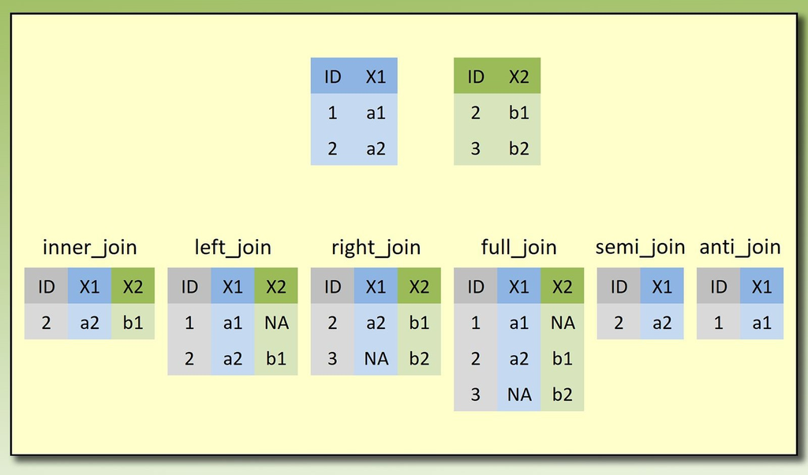

```r
# Lectura de datos
library(nycflights13)
flights
```

```
# A tibble: 336,776 × 19
    year month   day dep_time sched_dep_time dep_delay arr_time sched_arr_time
   <int> <int> <int>    <int>          <int>     <dbl>    <int>          <int>
 1  2013     1     1      517            515         2      830            819
 2  2013     1     1      533            529         4      850            830
 3  2013     1     1      542            540         2      923            850
 4  2013     1     1      544            545        -1     1004           1022
 5  2013     1     1      554            600        -6      812            837
 6  2013     1     1      554            558        -4      740            728
 7  2013     1     1      555            600        -5      913            854
 8  2013     1     1      557            600        -3      709            723
 9  2013     1     1      557            600        -3      838            846
10  2013     1     1      558            600        -2      753            745
# ℹ 336,766 more rows
# ℹ 11 more variables: arr_delay <dbl>, carrier <chr>, flight <int>,
#   tailnum <chr>, origin <chr>, dest <chr>, air_time <dbl>, distance <dbl>,
#   hour <dbl>, minute <dbl>, time_hour <dttm>
```

```r
planes
```

```
# A tibble: 3,322 × 9
   tailnum  year type              manufacturer model engines seats speed engine
   <chr>   <int> <chr>             <chr>        <chr>   <int> <int> <int> <chr>
 1 N10156   2004 Fixed wing multi… EMBRAER      EMB-…       2    55    NA Turbo…
 2 N102UW   1998 Fixed wing multi… AIRBUS INDU… A320…       2   182    NA Turbo…
 3 N103US   1999 Fixed wing multi… AIRBUS INDU… A320…       2   182    NA Turbo…
 4 N104UW   1999 Fixed wing multi… AIRBUS INDU… A320…       2   182    NA Turbo…
 5 N10575   2002 Fixed wing multi… EMBRAER      EMB-…       2    55    NA Turbo…
 6 N105UW   1999 Fixed wing multi… AIRBUS INDU… A320…       2   182    NA Turbo…
 7 N107US   1999 Fixed wing multi… AIRBUS INDU… A320…       2   182    NA Turbo…
 8 N108UW   1999 Fixed wing multi… AIRBUS INDU… A320…       2   182    NA Turbo…
 9 N109UW   1999 Fixed wing multi… AIRBUS INDU… A320…       2   182    NA Turbo…
10 N110UW   1999 Fixed wing multi… AIRBUS INDU… A320…       2   182    NA Turbo…
# ℹ 3,312 more rows
```

```r
# Ejemplo de unión (por la izquierda): left_join
# Debe usarse el argumento 'by =' para evitar errores o malas
# asignaciones automáticas.
# Ejemplos de otras operaciones en pueden encontrarse en:
# https://cran.r-project.org/web/packages/dplyr/vignettes/two-table.html
flights_planes <- left_join(flights, planes, by = "tailnum") %>%
  select(month, day, dep_time, arr_time,
         carrier, flight, tailnum, model)
flights_planes
```

```
# A tibble: 336,776 × 8
   month   day dep_time arr_time carrier flight tailnum model
   <int> <int>    <int>    <int> <chr>    <int> <chr>   <chr>
 1     1     1      517      830 UA        1545 N14228  737-824
 2     1     1      533      850 UA        1714 N24211  737-824
 3     1     1      542      923 AA        1141 N619AA  757-223
 4     1     1      544     1004 B6         725 N804JB  A320-232
 5     1     1      554      812 DL         461 N668DN  757-232
 6     1     1      554      740 UA        1696 N39463  737-924ER
 7     1     1      555      913 B6         507 N516JB  A320-232
 8     1     1      557      709 EV        5708 N829AS  CL-600-2B19
 9     1     1      557      838 B6          79 N593JB  A320-232
10     1     1      558      753 AA         301 N3ALAA  <NA>
# ℹ 336,766 more rows
```

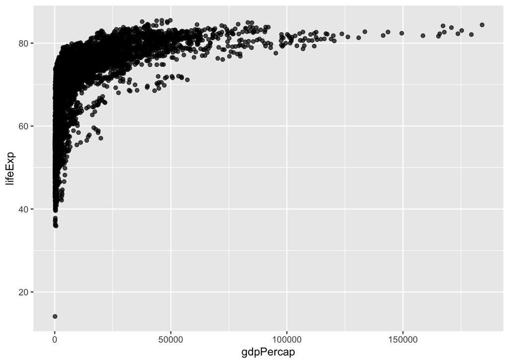

```r
# Gramática de gráficas (ggplot2) [https://ggplot2.tidyverse.org/]
# (https://es.r4ds.hadley.nz/03-visualize.html)
gapminder <- gapminder %>%
   filter(year>=1980) %>%
   select(year, region, country, pop, lifeExp, gdpPercap)
gapminder <- gapminder %>% na.omit()
gapminder <- arrange(gapminder, year)
# Gráfica 1: diagrama de puntos básico
ggplot(data = gapminder, aes(x = gdpPercap, y = lifeExp)) +
  geom_point(alpha = 0.7)
```

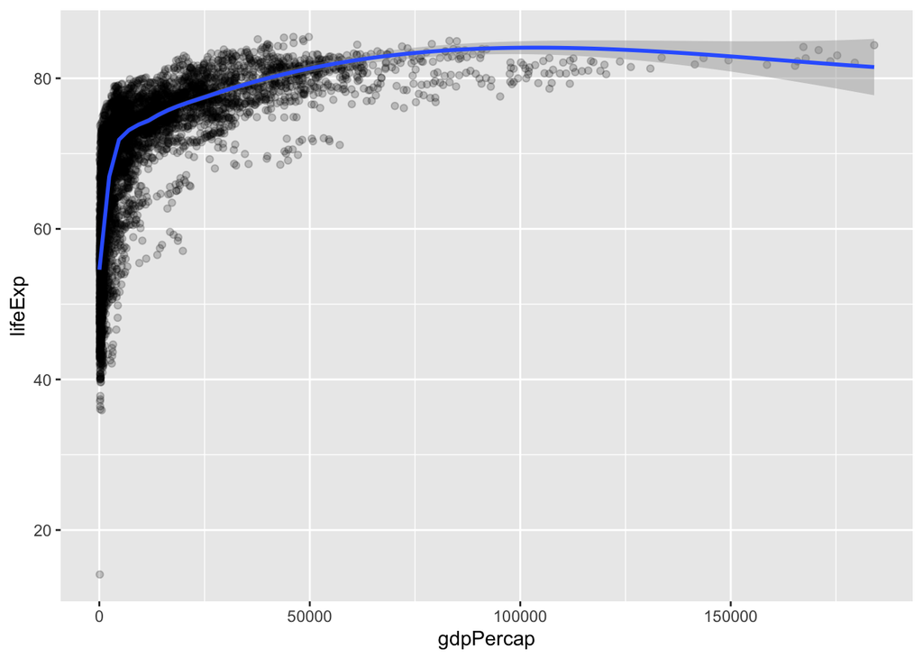

```r
# Gráfica 2: con ajuste no paramétrico
ggplot(data = gapminder, aes(x = gdpPercap, y = lifeExp)) +
  geom_point(alpha = 0.2) + geom_smooth(method = "loess")
```

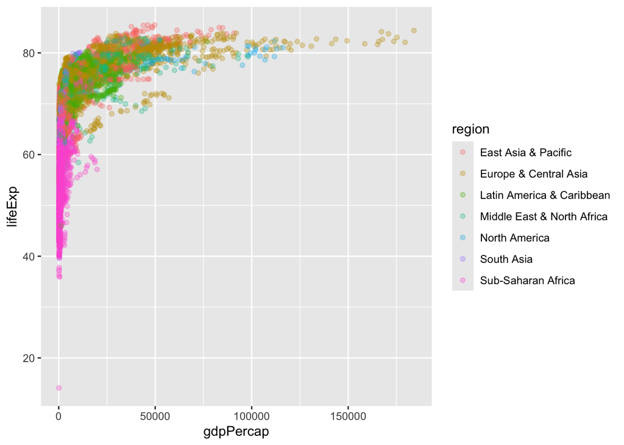

```r
# Gráfica 3: colores por regiones
ggplot(data = gapminder, aes(x = gdpPercap, y = lifeExp)) +
  geom_point(aes(col = region), alpha = 0.3)
```

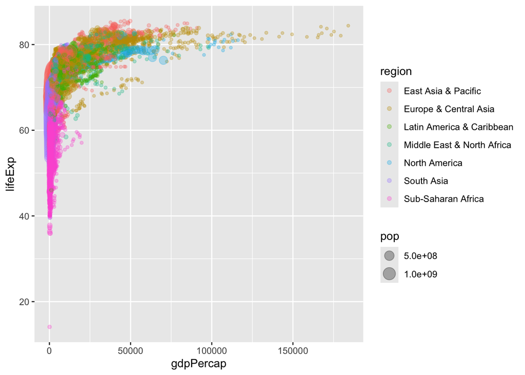

```r
# Gráfica 4: colores por regiones y tamaño por población
ggplot(data = gapminder, aes(x = gdpPercap, y = lifeExp)) +
  geom_point(aes(size = pop, col = region), alpha = 0.3)
```

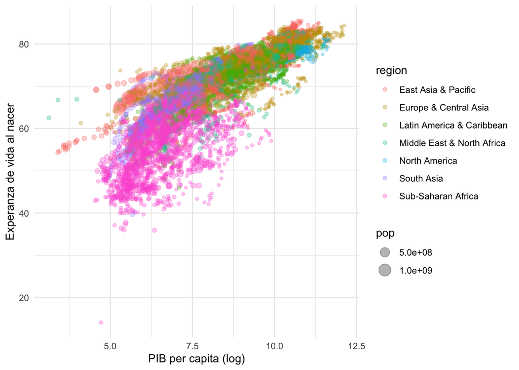

```r
# Gráfica 5: colores por regiones y tamaño por población (escala: log)
gapminder <-  gapminder %>% mutate(l_gdpPercap=log(gdpPercap))
ggplot(data = gapminder, aes(x = l_gdpPercap, y = lifeExp)) +
    geom_point(aes(size = pop, col = region), alpha = 0.3) +
    labs(x = "PIB per capita (log)", y = "Experanza de vida al nacer") +
    theme_minimal() # Tema b&w
```

```r
# Gráfica 6 (interactiva): burbujas de Hans-Rosling
# (https://www.gapminder.org/fw/world-health-chart/)
# Escalas de color: https://cran.r-project.org/web/packages/viridis/index.html
# Librería gganimate: https://gganimate.com/
# Librería plotly en R: https://plotly.com/r/
library(viridis)
library(gganimate)
library(plotly)
plot_ly(gapminder,
        y = ~lifeExp,
        x = ~l_gdpPercap,
        frame = ~year,
        type = 'scatter',
        mode = 'markers',
        size = ~pop,
        color = ~region,
        colors = 'Set1') %>%
    layout(xaxis = list(title = "PIB per capita (log)"),
           yaxis = list(title = "Experanza de vida al nacer"))
```

[interactive chart not shown]

**Código Python**

En las siguientes páginas web se pueden encontrar los detalles sobre la gestión ’*a la tidyverse’* de datos y la realización de gráficos en Python:

1. librería `pandas`:

   https://pandas.pydata.org/docs/user_guide/index.html

   https://wesmckinney.com/book/accessing-data

   https://wesmckinney.com/book/data-cleaning

   https://wesmckinney.com/book/data-wrangling
2. librería `plotnine`: https://plotnine.readthedocs.io/en/stable/

En términos generales, para aprender cómo hacer “ciencia de datos” con Python se puede consultar el libro de McKinney: https://wesmckinney.com/book/.

```python
# Lectura de librerías
import numpy as np
import pandas as pd
import matplotlib.pyplot as plt
from plotnine import *
# Lectura de datos
gapminder = pd.read_csv('data/GAPMINDER.csv')
gapminder.shape
```

```
(13454, 8)
```

```python
gapminder.columns
```

```
Index(['iso2c', 'iso3c', 'country', 'date', 'NY.GDP.PCAP.CD', 'SP.DYN.LE00.IN',
       'SP.POP.TOTL', 'region'],
      dtype='object')
```

```python
gapminder.info()
```

```
<class 'pandas.core.frame.DataFrame'>
RangeIndex: 13454 entries, 0 to 13453
Data columns (total 8 columns):
 #   Column          Non-Null Count  Dtype
---  ------          --------------  -----
 0   iso2c           13392 non-null  object
 1   iso3c           13454 non-null  object
 2   country         13454 non-null  object
 3   date            13454 non-null  int64
 4   NY.GDP.PCAP.CD  10346 non-null  float64
 5   SP.DYN.LE00.IN  12890 non-null  float64
 6   SP.POP.TOTL     13424 non-null  float64
 7   region          13454 non-null  object
dtypes: float64(3), int64(1), object(4)
memory usage: 841.0+ KB
```

```python
# Cambio de nombres de variables
gapminder.rename(columns={'date': 'year'}, inplace=True)
gapminder.rename(columns={'NY.GDP.PCAP.CD': 'gdpPercap'}, inplace=True)
gapminder.rename(columns={'SP.DYN.LE00.IN': 'lifeExp'}, inplace=True)
gapminder.rename(columns={'SP.POP.TOTL': 'pop'}, inplace=True)
# Datos iniciales y finales
gapminder.head()
```

```
  iso2c iso3c country  ...  lifeExp      pop                     region
0    AW   ABW   Aruba  ...   64.152  54608.0  Latin America & Caribbean
1    AW   ABW   Aruba  ...   64.537  55811.0  Latin America & Caribbean
2    AW   ABW   Aruba  ...   64.752  56682.0  Latin America & Caribbean
3    AW   ABW   Aruba  ...   65.132  57475.0  Latin America & Caribbean
4    AW   ABW   Aruba  ...   65.294  58178.0  Latin America & Caribbean

[5 rows x 8 columns]
```

```python
gapminder.tail()
```

```
      iso2c iso3c   country  ...  lifeExp         pop              region
13449    ZW   ZWE  Zimbabwe  ...   60.709  14751101.0  Sub-Saharan Africa
13450    ZW   ZWE  Zimbabwe  ...   61.414  15052184.0  Sub-Saharan Africa
13451    ZW   ZWE  Zimbabwe  ...   61.292  15354608.0  Sub-Saharan Africa
13452    ZW   ZWE  Zimbabwe  ...   61.124  15669666.0  Sub-Saharan Africa
13453    ZW   ZWE  Zimbabwe  ...   59.253  15993524.0  Sub-Saharan Africa

[5 rows x 8 columns]
```

```python
# Operaciones del tidyverse con Pandas
# select
gapminder_selected = gapminder[['year','country', 'pop', 'gdpPercap']]
# filter
gapminder_filtered = gapminder_selected[(gapminder_selected["year"] >= 1980)]
# mutate
gapminder_filtered['GDP'] = gapminder_filtered['gdpPercap'] * gapminder_filtered['pop']
# groupby
gapminder_grouped = gapminder_filtered.groupby('country')
# summarise
gapminder_summarised = gapminder_grouped['GDP'].mean()
gapminder_summarised = gapminder_summarised.dropna()
# arrange (sort)
gapminder_summarised.sort_values(ascending=False).head(10)
```

```
country
United States     1.113049e+13
China             4.117048e+12
Japan             4.101114e+12
Germany           2.481413e+12
United Kingdom    1.819280e+12
France            1.788376e+12
Italy             1.436080e+12
Brazil            1.031871e+12
India             9.960817e+11
Canada            9.955903e+11
Name: GDP, dtype: float64
```

```python
gapminder_summarised.sort_values(ascending=True).head(10)
```

```
country
Tuvalu                   2.688518e+07
Kiribati                 9.964231e+07
Nauru                    1.021136e+08
Marshall Islands         1.287742e+08
Palau                    2.140444e+08
Tonga                    2.477645e+08
Micronesia, Fed. Sts.    2.511701e+08
Sao Tome and Principe    2.563795e+08
Dominica                 3.359127e+08
Vanuatu                  4.166275e+08
Name: GDP, dtype: float64
```

```python
# Se obtiene el mismo resultado con nlargest y nsmallest
gapminder_summarised.nlargest(10)
```

```
country
United States     1.113049e+13
China             4.117048e+12
Japan             4.101114e+12
Germany           2.481413e+12
United Kingdom    1.819280e+12
France            1.788376e+12
Italy             1.436080e+12
Brazil            1.031871e+12
India             9.960817e+11
Canada            9.955903e+11
Name: GDP, dtype: float64
```

```python
gapminder_summarised.nsmallest(10)
```

```
country
Tuvalu                   2.688518e+07
Kiribati                 9.964231e+07
Nauru                    1.021136e+08
Marshall Islands         1.287742e+08
Palau                    2.140444e+08
Tonga                    2.477645e+08
Micronesia, Fed. Sts.    2.511701e+08
Sao Tome and Principe    2.563795e+08
Dominica                 3.359127e+08
Vanuatu                  4.166275e+08
Name: GDP, dtype: float64
```

```python
# Tuberías en pandas: operaciones encadenadas con '.'
gapminder[(gapminder["year"] >= 1980)].groupby('region')['country'].nunique()
```

```
region
East Asia & Pacific           37
Europe & Central Asia         58
Latin America & Caribbean     42
Middle East & North Africa    21
North America                  3
South Asia                     8
Sub-Saharan Africa            48
Name: country, dtype: int64
```

```python
gapminder[(gapminder["year"] >= 1980)].groupby('year')['lifeExp'].mean()
```

```
year
1980    62.219302
1981    62.562886
1982    62.788927
1983    63.105528
1984    63.428057
1985    63.710139
1986    64.154868
1987    64.389125
1988    64.506298
1989    64.971556
1990    65.176808
1991    65.301840
1992    65.289795
1993    65.498318
```

[output cut: 29 more lines]

```python
gapminder[(gapminder["year"] >= 1980)].groupby(['year', 'region'])[['lifeExp', 'gdpPercap']].mean()
```

```
                                   lifeExp     gdpPercap
year region
1980 East Asia & Pacific         63.130124   4380.888303
     Europe & Central Asia       70.008017  12551.671629
     Latin America & Caribbean   65.929825   2036.051429
     Middle East & North Africa  62.922230   9305.049529
     North America               74.055317  11666.984839
...                                    ...           ...
2021 Latin America & Caribbean   72.968782  14167.117807
     Middle East & North Africa  74.367904  17286.260464
     North America               79.401959  78117.587729
     South Asia                  70.535375   3177.624523
     Sub-Saharan Africa          61.750413   2365.335575

[294 rows x 2 columns]
```

```python
# Unir, combinar y remodelar ficheros de datos
# (https://wesmckinney.com/book/data-wrangling)
flights = r.flights
planes = r.planes
flights_planes = flights.merge(planes, on = 'tailnum', how = 'left')
flights_planes_selected = flights_planes[['month', 'day', 'dep_time', 'arr_time', 'carrier', 'flight', 'tailnum', 'model']]
flights_planes_selected
```

```
        month  day    dep_time    arr_time carrier  flight tailnum     model
0           1    1         517         830      UA    1545  N14228   737-824
1           1    1         533         850      UA    1714  N24211   737-824
2           1    1         542         923      AA    1141  N619AA   757-223
3           1    1         544        1004      B6     725  N804JB  A320-232
4           1    1         554         812      DL     461  N668DN   757-232
...       ...  ...         ...         ...     ...     ...     ...       ...
336771      9   30 -2147483648 -2147483648      9E    3393    None       NaN
336772      9   30 -2147483648 -2147483648      9E    3525    None       NaN
336773      9   30 -2147483648 -2147483648      MQ    3461  N535MQ       NaN
336774      9   30 -2147483648 -2147483648      MQ    3572  N511MQ       NaN
336775      9   30 -2147483648 -2147483648      MQ    3531  N839MQ       NaN

[336776 rows x 8 columns]
```

```
<Figure Size: (640 x 480)>
```

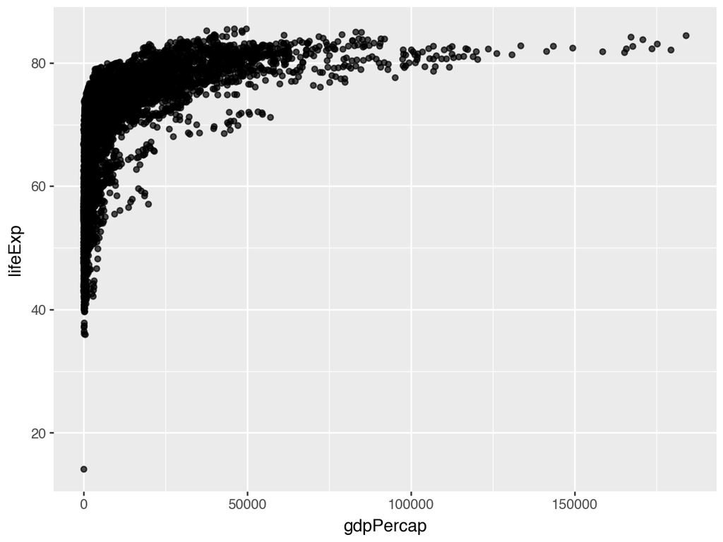

```python
# Operaciones gráficas del tidyverse con `plotnine`
gapminder = gapminder[(gapminder["year"] >= 1980)][['year', 'region', 'country', 'pop', 'lifeExp', 'gdpPercap']]
gapminder = gapminder.dropna()
gapminder['l_gdpPercap']=gapminder['gdpPercap'].map(lambda x:np.log(x))
gapminder = gapminder = gapminder.sort_values(by=['year'])
# Gráfica 1: diagrama de puntos básico
(
    ggplot(gapminder, aes(x='gdpPercap', y='lifeExp'))
    + geom_point(alpha=0.7)
    + labs(x='gdpPercap', y='lifeExp')
)
```

```
<Figure Size: (640 x 480)>
```

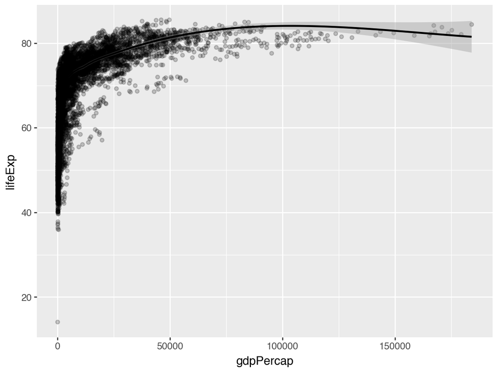

```python
# Gráfica 2: con ajuste no paramétrico
(
    ggplot(gapminder, aes(x='gdpPercap', y='lifeExp'))
    + geom_point(alpha=0.2) + geom_smooth(method = "loess")
    + labs(x='gdpPercap', y='lifeExp')
)
```

```
<Figure Size: (640 x 480)>
```

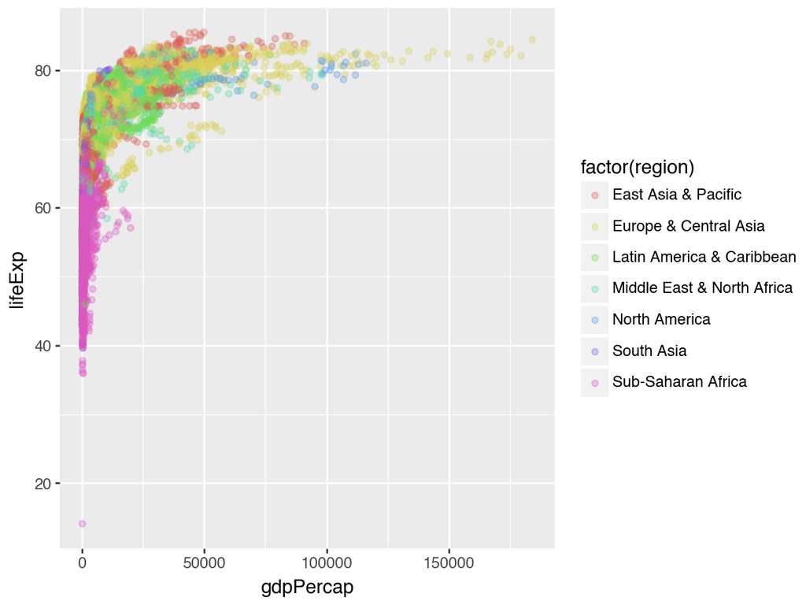

```python
# Gráfica 3: colores por regiones
(
    ggplot(gapminder, aes(x='gdpPercap', y='lifeExp', color='factor(region)'))
    + geom_point(alpha=0.3)
    +  labs(x='gdpPercap', y='lifeExp')
)
```

```
<Figure Size: (640 x 480)>
```

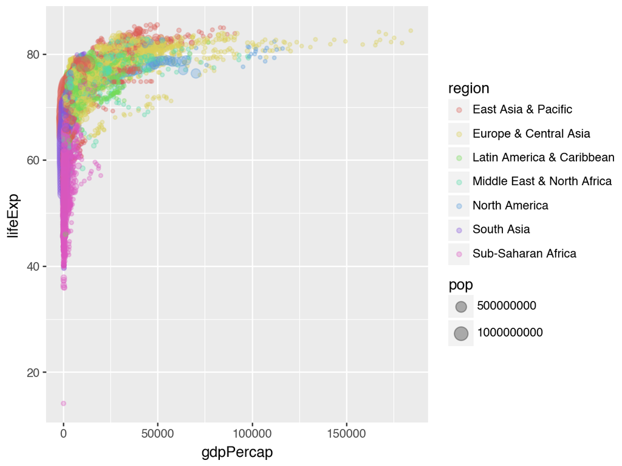

```python
# Gráfica 4: colores por regiones y tamaño por población
(
    ggplot(gapminder, aes(x='gdpPercap', y='lifeExp', color='region', size='pop'))
    + geom_point(alpha=0.3)
    +  labs(x='gdpPercap', y='lifeExp')
)
```

```
<Figure Size: (640 x 480)>
```

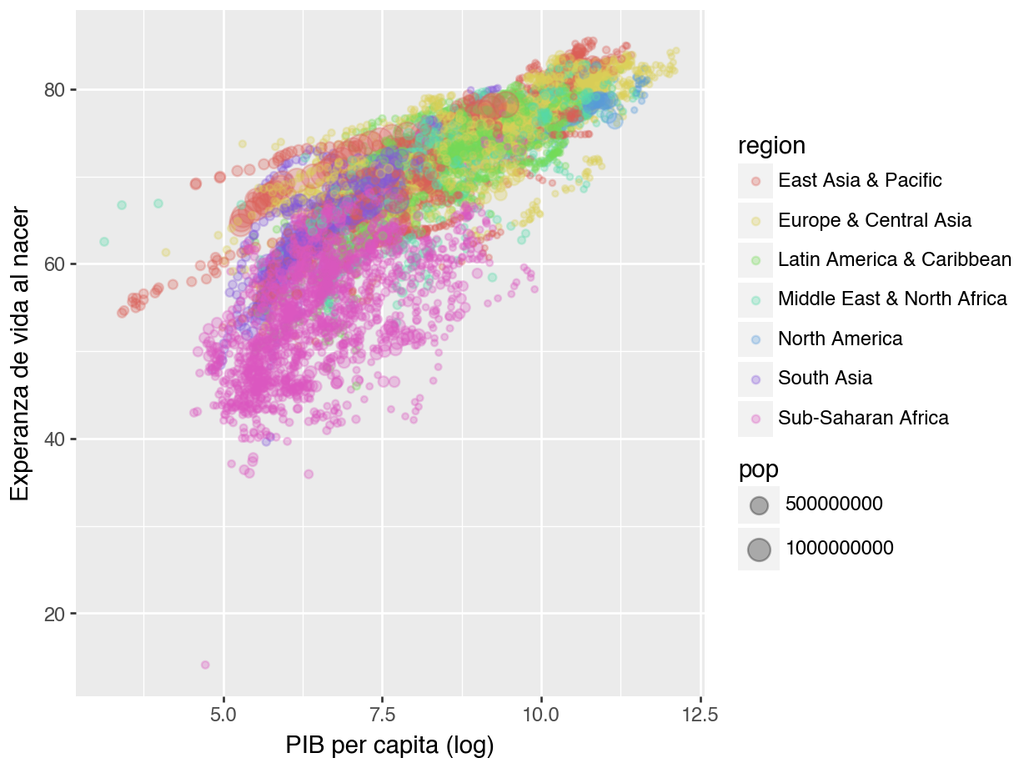

```python
# Gráfica 5: colores por regiones y tamaño por población (esc. log.)
(
    ggplot(gapminder, aes(x='l_gdpPercap', y='lifeExp', color='region', size='pop'))
    + geom_point(alpha=0.3)
    +  labs(x='PIB per capita (log)', y='Experanza de vida al nacer')
)
```

```python
# Gráfica 6 (interactiva): burbujas de Hans-Rosling
# Librería plotly en Python: https://plotly.com/python/
import plotly.express as px
px.scatter(gapminder,
            y = "lifeExp",
            x = "l_gdpPercap",
            hover_name = "country",
            hover_data= ['country'],
            color = "region",
            size = "pop", size_max = 45,
            animation_frame= 'year'
)
```

[interactive chart not shown]